# The Art of Visualization: The Good and the Bad

## Contents

- Part I. `Bad Visualization`
- Part II. `Why Are They Bad?`
- Part III. `Good Alternatives`
- Part IV. `Why Are They Good?`

## Part I. `Bad Visualization`

## Different ways population has been visualized:

- **Pie Chart**

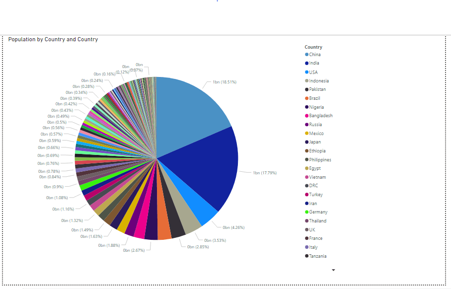

Population of Countries with Pie Chart

- Source: https://sranalytics.io/blog/bad-data-visualization-examples/

## Different ways population has been visualized:

- **Bubble Chart**

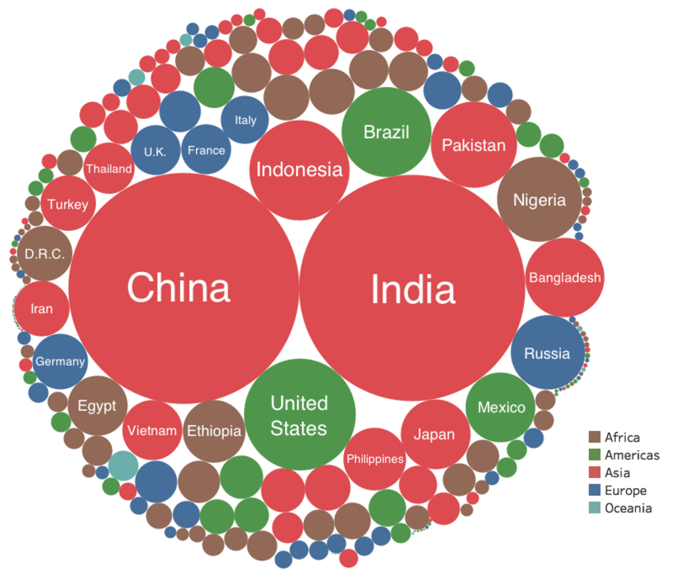

Population of Countries with Bubble Chart

- Source: https://www.weforum.org/stories/2019/04/the-world-s-7-5-billion-people-in-one-chart/

## Different ways population has been visualized:

- **Square Blocks**

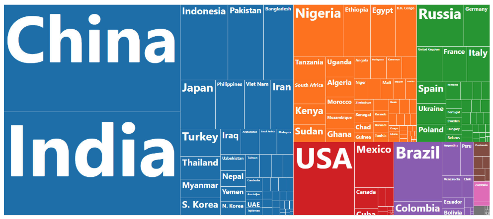

Population of Countries with Square Blocks

- Source: https://www.weforum.org/stories/2019/04/the-world-s-7-5-billion-people-in-one-chart/

## Part II. `Why Are They Bad?`

## Pie Chart

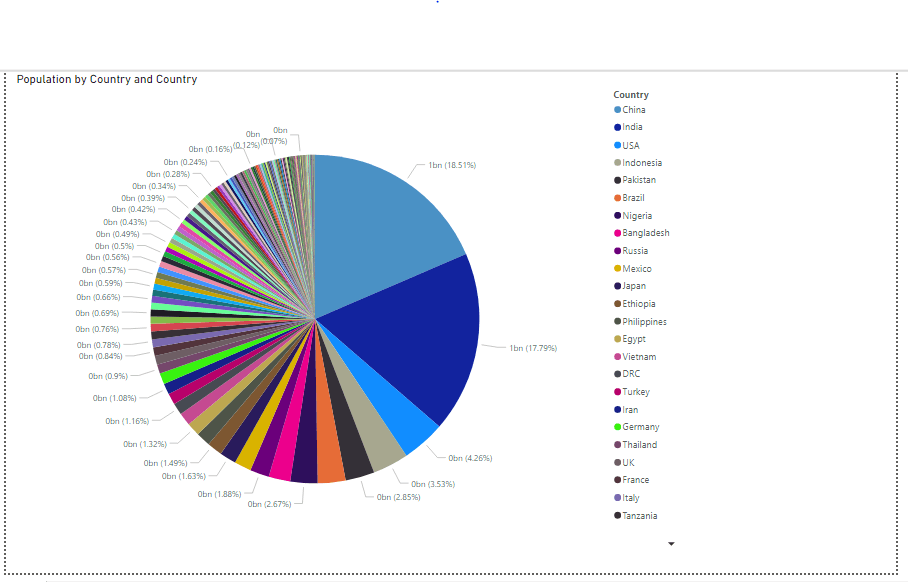

**Problems with This Visualization**

- The large number of countries in the dataset makes it difficult to display effectively in a pie chart.
- Countries with significantly large populations dominate the chart, leaving smaller countries nearly invisible.
- The visualization does not allow for easy comparison of countries with similar population sizes.

## Bubble Chart

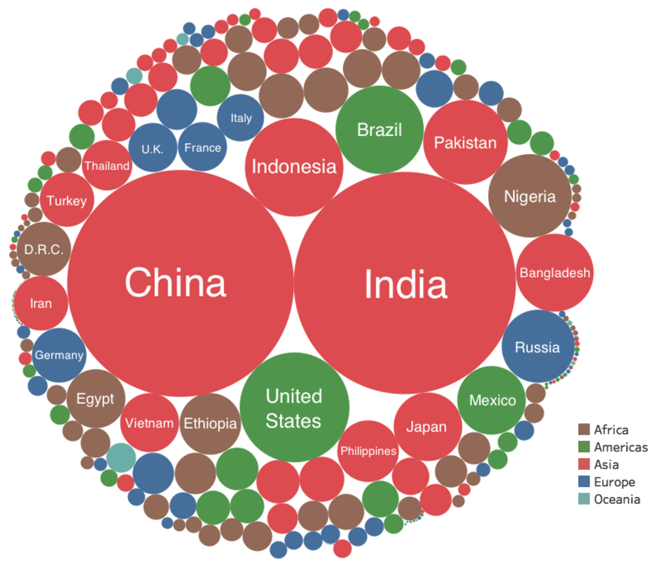

**Problems with This Visualization**

- Some bubbles are not labeled, making it difficult to identify the countries they represent.
- Exact population numbers are not visible; you can only make rough comparisons based on bubble size.
- The bubble shapes and sizes are hard to make comparisons precisely.

## Square Blocks

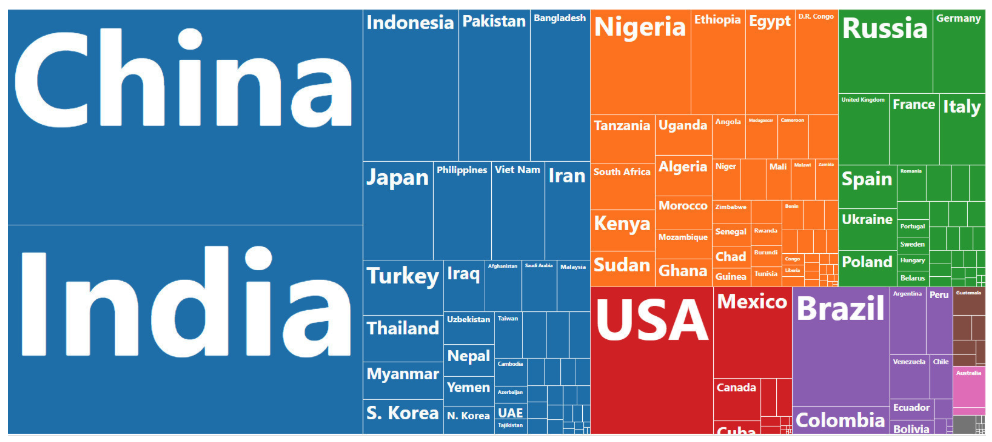

**Problems with This Visualization**

- Although visually creative, square blocks fail to provide any numerical data, which is crucial for understanding population sizes.
- While square blocks are easier to compare in terms of size than bubbles, the differences in population size are still difficult to assess accurately.

## Part III. `Good Alternatives`

## Interactive Bar Chart

[interactive chart not shown]

## Interactive World Map

[interactive chart not shown]

## Part IV. `Why Are They Good?`

## What-Why-How Analysis

**1. Interactive Bar Chart**

- **What**

An interactive bar chart displaying population data by country. It allows users to search, filter, and compare countries or regions based on different attributes.

- **Why**

To enable dynamic and engaging exploration of population data.

- **How**
- The bar chart uses the 2023 World Population Data sourced from the WDI library in R.
- The countrycode library in R is used to categorize data by continent, making the chart more user-friendly and informative.
- Interactive features include search functionality, sorting by population size, and hover-over tooltips displaying additional statistics.

## What-Why-How Analysis

**2. Interactive World Map**

- **What**

A dynamic map that visualizes the population data of countries across the globe.

- **Why**

To provide a geographic perspective of population distribution around the world.

- **How**
- The world map is built using the same 2023 World Population Data from the WDI library.
- By clicking or hovering over countries, users can view detailed population numbers.